# Juvenile Snowshoe Hares in Bonanza Creek Experimental Forest: Exploratory Report

#### B. Juvenile female and male hare weights

With an inital understanding of the number of hares per year, it would be important to incorporate other parameters to find any new relationships. A finalized figure (Figure 2) was created to consider sex and sampling locations. Through this figure, inital frequency assumptions about the distirbution of female and male hares through each field site could be made.

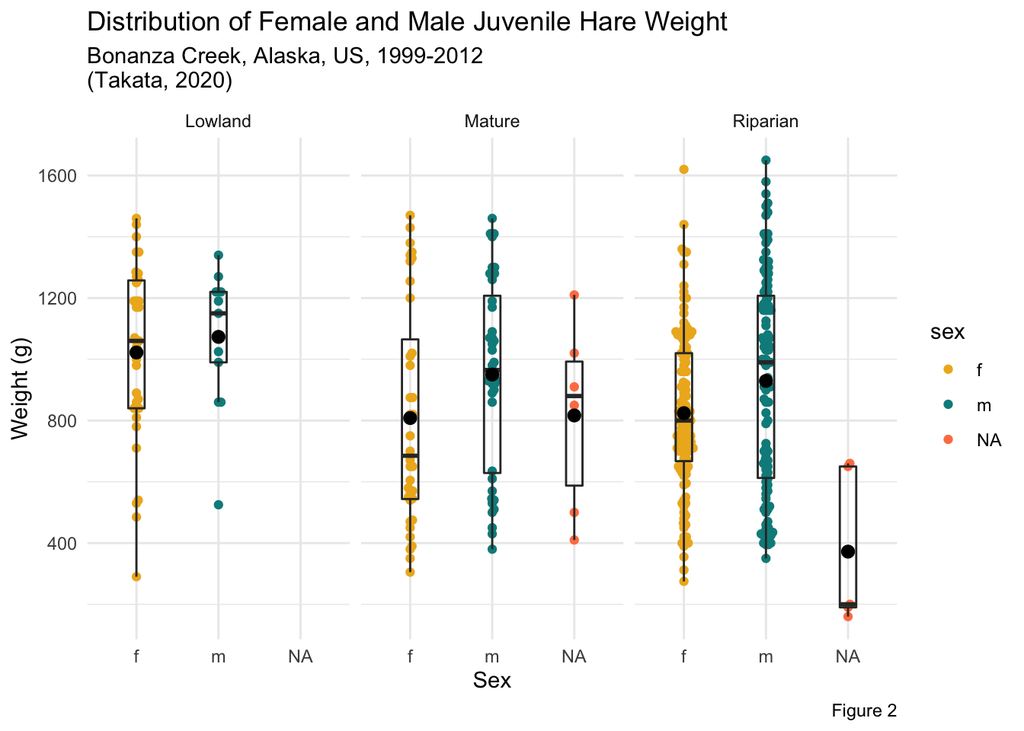

**Figure 2.** Weight (g) observations of female and male juvenile Bonanza Snowshoe hares in three sampling areas: Lowland, Mature, and Riparian. Points correspond to indviidual hare weight observations: gold (female), cyan (male), and coral (N/A, in which sex could not be determined). Overlayed box plots endpoints indicate the variation of measurents from the 1st and 3rd quartiles; the black line and point indciate the median and mean value for each sex, respectively. Data: Kielland et al. (2017)

The figure reveals a wide distribution of observations in both the Lowland and Mature sampling sites, with the Riparian site with more frequent, centrally located data. The Lowland has an overall higher mean and median than the other two locations. Of the different areas, the Riparian environment has a relativly normal, symmetric distribution with similar mean and median values. Both the female and male hares of the the Riparian sampling site, seem to display equal normalcy, with neither group more skewed than the other.Female and male groupings are not consistent through the sampling sites; the groups vary in their central tendency with a large spread in frequency of observations.

#### C. Juvenile Female and Male Weight Comparison and Descriptive Statistics

**Table 1.** Descriptive statistics (mean, standard deviation, and sample size) for recorded juvenile hare weight based on sex. Data: Kielland et al. (2017)

| Sex | Mean Weight (g) | Standard Deviation (g) | Sample Size |
| --- | --- | --- | --- |
| f | 855.3909 | 292.2526 | 200 |
| m | 945.8589 | 333.2151 | 163 |
| NA | 614.5455 | 357.5853 | 15 |

Weights (g) of the snowshoe hares were compared across female and male groupings. Male hares had a greater mean weight of 945.8589 +/- 333.2151 g, n = 163 with femles hares averaging 855.3909 +/- 292.2526 g when n = 200.